# Model Building with `caret` (Binary Outcomes)

### 1. Introduction

The [previous lab](https://remiller1450.github.io/s230f19/caret1.html) introduced the `caret` package, which contains a suite of functions used to build and compare different supervised learning models with an empthasis on *out-of-sample* performance.

This lab will focus on modeling *binary categorical* outcomes, a type of modeling sometimes referred to as *classification*. We begin by loading the following packages:

```r
library(ggplot2) ## For plotting
library(caret)   ## For model fitting and evaluation
library(visreg)  ## For visualizing regression models
library(plotROC) ## For constructing ROC curves
library(mgcv)    ## For fitting GAM models
library(kernlab) ## Contains an example dataset
library(glmnet)  ## For fitting regularized models
```

### 2. Binary Outcomes and Logistic Regression

The simplest categorical variables are *binary*, meaning only two categories are possible.

Survival status is an example of a binary variable. The Donner Party dataset documents the fate of members of the [Donner Party](https://en.wikipedia.org/wiki/Donner_Party), a group of 45 pioneers whose migration to California was delayed by a series of mishaps which resulted in the group being stranded in the Sierra Nevada mountains.

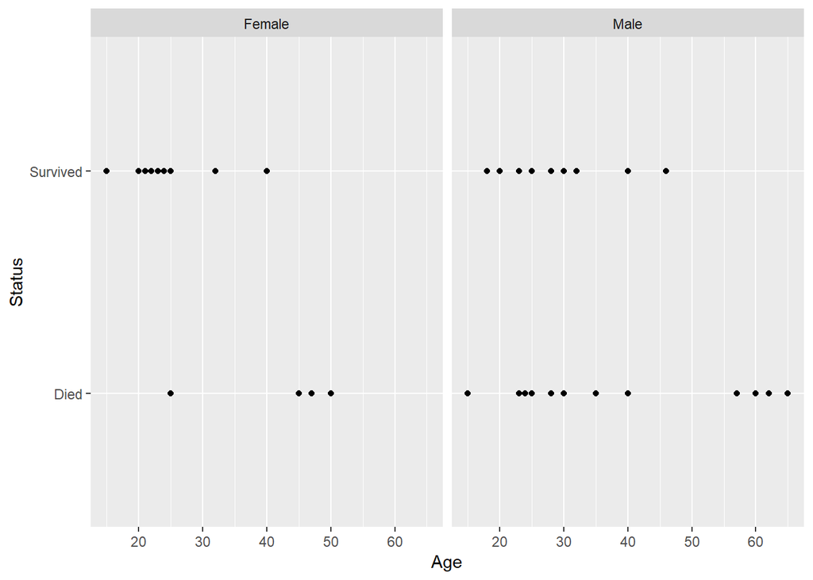

```r
## Load the Donner Party data and plot it
donner <- read.delim("https://web.as.uky.edu/statistics/users/pbreheny/760/data/donner.txt")
ggplot(donner, aes(x = Age, y = Status)) + geom_point() + facet_wrap(~Sex)
```

Visual inspection suggests the variables `Age` and `Sex` are related to the binary outcome of survival.

A *naive analysis* would re-code the binary variable `Status` as the numeric values 1 and 0, then model this re-coded variable using linear regression. On the surface this approach is appealing, the model’s predictions can be viewed as predicted probabilities of the category coded as “1”, and the effect of each the explanatory variables on this probability is easy to interpret.

We’ll soon see that the naive approach described above is problematic, but we’ll first need to introduce some notation. Throughout this lab, we’ll denote the probability of category “1” as $\pi$, thus the corresponding estimate from a model is denoted $\hat{\pi}$.

Putting things together in one place:

- $y_i$ is the $i^{th}$ observation’s category (possibly re-coded as 1 or 0)
- $\pi_i$ is the *true probability* that $y_i =$ “Category 1”
- $\hat{pi}_i$ is the *estimated probability* that $y_i =$ “Category 1”

Now let’s see what the linear regression model using a re-coded outcome (with surviving coded as 1) looks like for the Donner Party data:

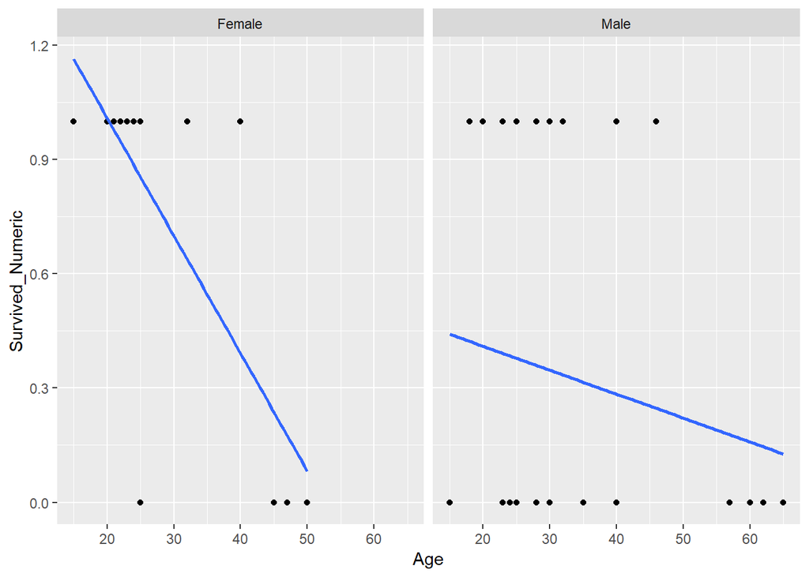

```r
donner$Survived_Numeric <- as.numeric(donner$Status == "Survived")

ggplot(donner, aes(x = Age, y = Survived_Numeric)) + geom_point() +
  geom_smooth(method = "lm", se = FALSE) + facet_wrap(~Sex)
```

There are clearly a few problems with this model, the most obvious being the model’s *impossible* predictions for the survival probabilities of young females (notice $\hat{\pi}_{\text{Fem, Age}=18}>100\%$).

A better way of modeling binary outcomes is the *logistic regression* model:
$$log\big(\tfrac{\pi}{1-\pi}\big) = \beta_0 + \beta_1X_1 + \ldots + \beta_pX_p$$

In words, logistic regression models the *natural log of the odds of category “1”* as a linear combination of explanatory variables $\{X_1, \ldots, X_p\}$.

**Note**: The term “odds” refers to the ratio of the probability of an outcome occurring, relative to the probability of the outcome not occurring (ie: $\tfrac{\pi}{1-\pi}$). So an odds of 3 (sometimes described as “3 to 1 odds”) means that you’d expect 3 occurrences of category “1” for each occurrence of category “0”.

In logistic regression the *response*, or the probability of category “1”, can be expressed:
$$\pi = \frac{\exp(\beta_0 + \beta_1X_1 + \ldots + \beta_pX_p )}{1 + \exp(\beta_0 + \beta_1X_1 + \ldots + \beta_pX_p )}$$
So while the relationship between any predictor $X_j$ and $\pi$ is clearly non-linear, you should recognize that logistic regression is still a *linear model*.

**Remark**: Statisticians use the phrase “linear model” to describe how explanatory variables contribute to a model. In logistic regression, each variable still makes a *separate additive contribution*. The relationship between these contributions and the outcome is determined by a [link function](https://support.minitab.com/en-us/minitab/18/help-and-how-to/modeling-statistics/regression/supporting-topics/logistic-regression/link-function/). For logistic regression, the link function is $g(\pi) = log\big(\tfrac{\pi}{1-\pi}\big)$, often called the “logit” link.

To fit a logistic regression model in `R` we use the `glm` function with the argument `family = "binomial"`:

```r
fit <- glm(Status ~ Age + Sex, data = donner, family = "binomial")
```

We can visually understand this model using the `visreg` package, which we’ll use to plot the relationship between the explanatory variable `Age` and the outcome (probability of survival) on the **response scale**.

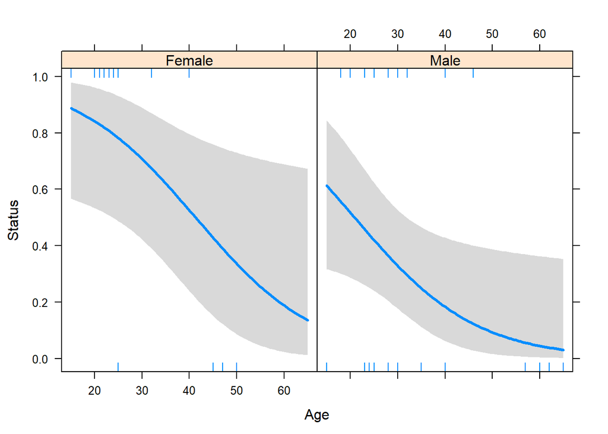

```r
visreg(fit, xvar = "Age", by = "Sex", scale = "response")
```

We could also plot the effect of `Age` vs. survival on the **log-odds** scale using the argument `scale = “linear”.

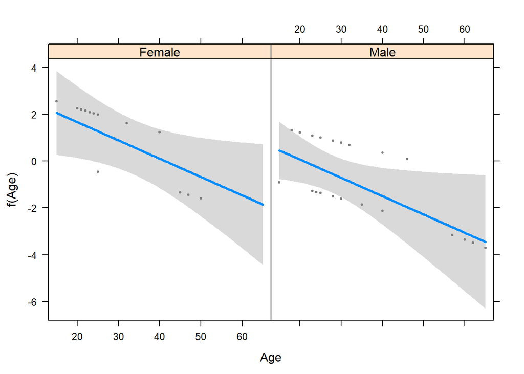

```r
visreg(fit, xvar = "Age", by = "Sex", scale = "linear")
```

As was the case with linear regression models, we can also understand this model by printing its estimated coefficients using the `coef` function:

```r
coef(fit)
```

```
## (Intercept)         Age     SexMale
##  3.23041381 -0.07820407 -1.59729350
```

When interpreting the estimates $\{\hat{\beta}_0, \hat{\beta}_1, \ldots \hat{\beta}_p \}$ for logistic regression we need to recognize that each coefficient represents an additive linear contribution *on the log-odds scale*.

So, in the Donner Party example, each 1 year increase in age *decreases the log-odds of survival by 0.078*. Unfortunately this isn’t a very easily understood interpretation, but luckily:
$$log\big(\tfrac{\pi}{1-\pi}\big) = \beta_0 + \beta_1X_1 + \ldots + \beta_pX_p \\ \implies \tfrac{\pi}{1-\pi} = exp(\beta_0 + \beta_1X_1 + \ldots + \beta_pX_p) \\
\implies \tfrac{\pi}{1-\pi} = exp(\beta_0)*exp(\beta_1X_1)* \ldots *exp(\beta_pX_p)$$

Based upon the expression above, we can interpret: - The exponent of the intercept ($e^{\beta_0}$) as the *baseline odds* of category “1”. - The exponent of any coefficient (ie: $e^{\beta_1}$) as a *multiplier of the baseline odds* for each one unit increase in that explanatory variable.

For the Donner Party example, the coefficient estimate of age, $\hat{\beta}_1 = -0.078$, can be exponentiated: $e^{-0.078} = 0.92$, which suggests that the odds of survival change by a factor of 0.92 for each 1 year increase in age. Equivalently, we might interpret this effect as a 8% decrease in the odds of survival for every 1 year increase in age.

**Question #1**:

Fit a logistic regression model that uses `Age` but *does not* use `Sex` as a predictor. What is the estimated effect of `Age` on survival status on the log-odds scale? How would you interpret the effect of a one year increase in age?

### 3. Performance Measures

Now that we’ve seen how to fit and interpret a logistic regression model, we’ll next need to learn how to evaluate its performance. Recall that we’ve previously evaluated models using cross-validation to estimate out-of-sample root mean squared error (RMSE) and mean absolute error (MAE):
$$RMSE = \sqrt{\tfrac{1}{n}\sum_i (y_i - \hat{y}_i)^2} \qquad MAE = \tfrac{1}{n}\sum_i|y_i - \hat{y}_i|$$

Generally speaking, neither of these measures can be calculated when $y_i$ and $\hat{y}_i$ are categorical, prompting us to seek alternative measures of model performance. The subsections that follow will introduce a few of these alternatives.

#### Accuracy

The simplest measure of model performance for binary outcomes is *accuracy*, or the proportion of correct classifications the model makes: $\text{Accuracy} = \Sigma_{i=1}^{n}(y_i = \hat{y}_i)/n$.

Calculating accuracy requires the data analyst to map the model’s predicted probabilities into predicted categories using a decision rule:
$$\hat{y}_i = 1 \text{ if } \hat{\pi}_i \geq t; \\ \hat{y}_i=0 \text{ if } \hat{\pi}_i<t$$

In most circumstances, $t = 0.5$ is a reasonable choice as it implies predicted probabilities are mapped to the “most likely” category.

For a logistic regression model fit using the `glm` function, predicted probabilities are returned as a list element named `fitted.values`. The code below shows how to use the `ifelse` function to transform these probabilities into predicted categories:

```r
fit <- glm(Status ~ Age + Sex, data = donner, family = "binomial")
predictedCategory <- ifelse(fit$fitted.values > .5, "Survived", "Died")
```

We can then calculate accuracy by finding the proportion of these predictions which match the actual observed outcome:

```r
sum(donner$Status == predictedCategory)/length(donner$Status)
```

```
## [1] 0.7777778
```

We see that this logistic regression model achieves 78% accuracy, although we should note that this is *in-sample* accuracy.

Relying upon *in-sample* accuracy can be valuable if we only want to understand the Donner Party, but if want to generalize this model to other survival situations we’ll want to look at *out-of-sample* accuracy. Later in this lab we’ll see how to use cross-validation to estimate *out-of-sample* accuracy.

**Question #2**:

Calculate the accuracy of the logistic regression model you fit in Question 1 using a decision threshold of 0.5. Is this model’s accuracy higher or lower than the model that also includes `Sex` (the model shown above with 78% accuracy)?

#### Kappa

Accuracy is a popular performance measure because it’s easy to understand and use to make decisions, but relying solely on accuracy can be problematic when one category is much more common than the other. For example, consider a model designed to predict whether a Grinnell College student will graduate in four years. Suppose this model achieves 85% accuracy, which sounds like pretty good performance.

However, the reality is that 85% of all Grinnell students end up graduating in four years, which means that an uninformative model that simply predicts “graduate” for everyone can trivially achieve 85% accuracy. In other words, accuracy by itself won’t always reflect how useful the model is. Instead, we’d like to know by what degree are a model’s predictions *more accurate* than what could be expected by random chance.

[Cohen’s kappa](https://en.wikipedia.org/wiki/Cohen%27s_kappa), denoted as $\kappa$, is a statistic originally designed to measure inter-rater reliability, but it is frequently used to measurement the agreement between a model’s predictions and the actual data.
$$\kappa = \tfrac{p_o - p_e}{1 - p_e}$$

Here, $p_o$ is the observed accuracy from the model, and $p_e$ is the expected accuracy under random chance.

In the Grinnell graduation example, $p_o = 0.85$, as the model achieved 85% accuracy. Also, $p_e = 0.85$ because an uninformative model could achieve 85% accuracy. Thus, $\kappa = 0$ in this example.

In contrast, suppose we had a perfect model which could predict graduation with 100% accuracy. In this case, $p_o = 1.00$ and $p_e = 0.85$, leading to $\kappa = 1$. Thus, kappa values nearer to 1 indicate better classification performance, while values nearer zero indicate classification indicate worse performance.

Note, it is possible for kappa to be negative if a model makes predictions that are worse than random chance.

**Question #3**:

Calculate Cohen’s kappa for the logistic regression model you used in Questions 1 and 2 to predict survival status using `Age`. How would you interpret this measure?

#### Sensitivity, Specificity, and AUC

In some applications certain types of misclassifications can be more harmful than others. For example, it is much less problematic for a model to classify a healthy person as having cancer than it is a model to classify a person with cancer as being healthy. The former might lead to some inconveniences, while the later will certainly result in grave health consequences.

These two different types of misclassification give rise to terms *false positive*, which describes when a “negative” observation is classified as “positive”, and *false negative*, which describes when a “positive” observation is classified as “negative”.

Like how we previously re-coded binary categories as “1” and “0”, it is up to the analyst to decide which categories to designate as “positive” and “negative”.

**Sensitivity** is defined as the *true positive rate*:
$$\text{Sensitivity} = \tfrac{\text{#True Positives}}{\text{#True Positives + #False Negatives}}$$
Put differently, sensitivity is the ability of a model to correctly classify an observation as “positive”, as the denominator represents the total number of “positive” observations, and the numerator represents the number correctly classified.

**Specificity** is defined as the *true negative rate*:
$$\text{Specificity} = \tfrac{\text{#True Negatives}}{\text{#True Negatives + #False Positives}}$$
So, specificity is the ability of a model to correctly classify an observation as “negative”, as the denominator represents the total number of “negative” observations, and the numerator represents the number correctly classified.

Note, a model that classifies everything as “positive” will have a sensitivity of 1 and a specificity of 0. Conversely, a model that classifies everything as “negative” will have a sensitivity of 0 and a specificity of 1.

For all non-trivial models there is a trade-off between sensitivity and specificity that depends upon the classification threshold, $t$, which is used to map predicted probabilities to categories. One way to visually represent this trade-off is a Receiver Operating Characteristics (ROC) curve.

The code below shows the ROC curve for the Donner Party logistic regression model created using `ggplot` via the `plotROC` package. The aesthetic “d” signifies the true “disease” status, while “m” signifies the “marker”, or the predicted probability of disease. By default, `geom_roc` will take the first level of the binary categorical outcome to be the “positive” class.

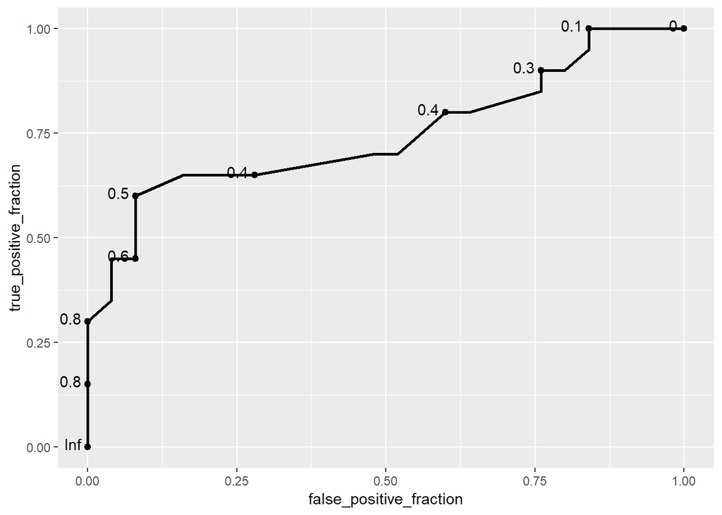

```r
fit <- glm(Status ~ Age + Sex, data = donner, family = "binomial")

df <- data.frame(Status = donner$Status, Prob = fit$fitted.values)
ggplot(df, aes(d = Status, m = Prob)) + geom_roc()
```

The y-axis of the ROC plot depicts the true positive rate, or sensitivity, while the x-axis shows the false positive rate, which is the same as 1-specificity. The curve depicts the sensitivity and 1-specificity that result from different decision thresholds (values of $t$ as previously defined), which are marked at various points.

For example, the threshold $t = 0.5$ results in approximately 60% sensitivity and 92% specificity, indicating the model is good at predicting survival, but not as good at predictive death.

We could supply a color argument to produce separate ROC curves for males and females:

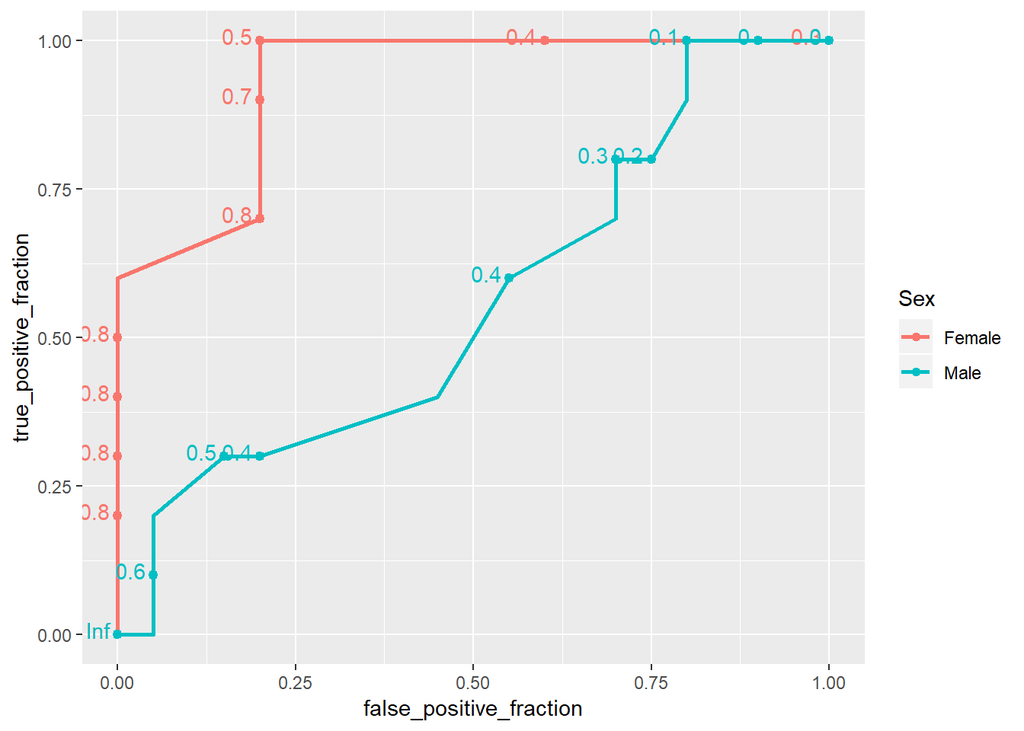

```r
fit <- glm(Status ~ Age + Sex, data = donner, family = "binomial")

df <- data.frame(Status = donner$Status, Prob = fit$fitted.values, Sex = donner$Sex)
ggplot(df, aes(d = Status, m = Prob, color = Sex)) + geom_roc()
```

Here we see that it is much more difficult to predict survival for males than for females in the Donner Party.

An ROC curve provide an overall picture of a model’s classification ability, but it is nice to have single number to summarize a model. The Area Under the Curve (AUC) of the ROC curve is a commonly used summary measure. An AUC of 1 indicates perfect classification, while an AUC of 0.5 is akin to random guessing.

The AUC of an ROC curve can be found using the `calc_auc` function in the `plotROC` package.

```r
plot1 <- ggplot(df, aes(d = Status, m = Prob)) + geom_roc()
plot2 <- ggplot(df, aes(d = Status, m = Prob, color = Sex)) + geom_roc()

calc_auc(plot1)
```

```
##   PANEL group   AUC
## 1     1    -1 0.746
```

```r
calc_auc(plot2)
```

```
##   PANEL group    AUC
## 1     1     1 0.9300
## 2     1     2 0.5575
```

`calc_auc` accepts a ggplot object containing an roc geom, and returns the area under the curve(s) for that plot.

### 4. Cross-Validation

Often we are interested in *out-of-sample* measures of model performance. Recall that ross-validation is one way of attaining *out-of-sample* performance estimates, we’ll use the `caret` package to perform cross-validation.

A strength of the `caret` package is that the same syntax can be used whether the model we are considering has a categorical or numeric outcome. The code below shows how to use `caret` to get cross-validated estimates of accuracy and Cohen’s kappa for our Donner Party model. If the `trainControl` and `train` workflow is unfamiliar, you should revisit the [Model Building with `caret` for Numeric Outcomes lab](https://remiller1450.github.io/s230f19/caret1.html).

```r
fit.control <- trainControl(method = "repeatedcv", number = 5, repeats = 10)

set.seed(123)
fit <- train(Status ~ Age + Sex, data = donner, method = "glm",
             family = "binomial", trControl = fit.control)

fit
```

```
## Generalized Linear Model
##
## 45 samples
##  2 predictor
##  2 classes: 'Died', 'Survived'
##
## No pre-processing
## Resampling: Cross-Validated (5 fold, repeated 10 times)
## Summary of sample sizes: 36, 36, 36, 36, 36, 36, ...
## Resampling results:
##
##   Accuracy  Kappa
##   0.72      0.4164745
```

Here we see that the 72% out-of-sample accuracy of our model is lower than the 78% in-sample accuracy we saw earlier. This tends to be the case for most models, particularly *overfit* models.

By default, `trainControl` tells the `train` function to report accuracy and kappa for categorical outcomes. Additional measures, such as sensitivity, specificity, and AUC, can be requested by using the `twoClassSummary` function in `trainControl` with the argument `classProbs = TRUE`:

```r
fit.control <- trainControl(method = "repeatedcv", number = 5, repeats = 10,
                            summaryFunction = twoClassSummary, classProbs = TRUE)

set.seed(123)
fit <- train(Status ~ Age + Sex, data = donner, method = "glm",
             family = "binomial", trControl = fit.control)

fit
```

```
## Generalized Linear Model
##
## 45 samples
##  2 predictor
##  2 classes: 'Died', 'Survived'
##
## No pre-processing
## Resampling: Cross-Validated (5 fold, repeated 10 times)
## Summary of sample sizes: 36, 36, 36, 36, 36, 36, ...
## Resampling results:
##
##   ROC   Sens   Spec
##   0.73  0.852  0.555
```

**Question #4**:

Use the `caret` package to evaluate the logistic regression model you’ve been using in Questions 1, 2, and 3. Based upon these results do you prefer this model, or do you prefer the model shown above (that also includes `Sex` as a predictor)?

### 5. Regularization

Regularization via the lasso penalty works for logistic regression in essentially the same way it did for linear regression. You should revisit the [Model Building with `caret` for Numeric Outcomes lab](https://remiller1450.github.io/s230f19/caret1.html) if you need a refresher on the lasso.

With a binary categorical outcome the only difference is we must specify `family = "binomial"` when using `glmnet`.

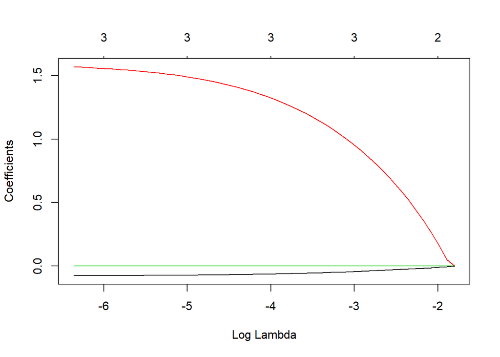

```r
X = model.matrix(data = donner[,1:2], ~ -1 + .) ## Set up the matrix including dummy vars
y = donner$Status

lasso <- glmnet(x = X, y = y, family = "binomial")
plot(lasso, xvar = "lambda")
```

We can compare our penalized logistic regression model with the unpenalized model using `caret`:

```r
lams <- expand.grid(alpha = 1, lambda = lasso$lambda) ## Extract lambda values

set.seed(123)
fit.lasso <- train(Status ~ Age + Sex, data = donner, method = "glmnet", family = "binomial",
                   trControl = fit.control, tuneGrid = lams)

set.seed(123)
fit.glm <- train(Status ~ Age + Sex, data = donner, method = "glm", trControl = fit.control)

rs <- resamples(list(GLM = fit.glm, LASSO = fit.lasso))
summary(rs)
```

```
##
## Call:
## summary.resamples(object = rs)
##
## Models: GLM, LASSO
## Number of resamples: 50
##
## ROC
##       Min. 1st Qu. Median  Mean 3rd Qu. Max. NA's
## GLM    0.4 0.63125   0.75 0.730     0.8    1    0
## LASSO  0.4 0.62500   0.75 0.729     0.8    1    0
##
## Sens
##       Min. 1st Qu. Median  Mean 3rd Qu. Max. NA's
## GLM    0.4     0.8    0.8 0.852       1    1    0
## LASSO  0.4     0.8    0.8 0.848       1    1    0
##
## Spec
##       Min. 1st Qu. Median  Mean 3rd Qu. Max. NA's
## GLM   0.25     0.5    0.5 0.555    0.75    1    0
## LASSO 0.25     0.5    0.5 0.550    0.75    1    0
```

In this example we see these two models are essentially identical. That isn’t unexpected, our dataset is fairly simple and doesn’t contain many variables, so regularization might be unnecessary. For larger datasets containing many predictors there is an increased potential for overfitting, it is these situations where the lasso tends to yield superior models.

### 6. Generalized Additive Models

Logistic regression assumes each explanatory variable makes an additive linear contribution to the expected log-odds of category “1”. The linearity assumption can be relaxed using generalized additive models of the form:

$$log\big(\tfrac{\pi}{1-\pi}\big) = \beta_0 + f_1(X_1) + \ldots + f_p(X_p)$$

Notice that if we take $f_j(X_j) = \beta_j X_j$ for all $j \in \{1, \ldots, p\}$ we arrive back at the usual logistic regression model.

As discussed in the previous lab, it is common to let $f_j$ be a spline function. This is done by default when using the `gam` function, or when specifying `method = "gam"` in `caret`’s `train` function.

The code below compares the performance of gam and ordinary logistic regression using `caret`:

```r
set.seed(123)
fit.glm <- train(Status ~ Age + Sex, data = donner, method = "glm", trControl = fit.control)

set.seed(123)
fit.gam <- train(Status ~ Age + Sex, data = donner, method = "gam", trControl = fit.control)

rs <- resamples(list(GLM = fit.glm, GAM = fit.gam))
summary(rs)
```

```
##
## Call:
## summary.resamples(object = rs)
##
## Models: GLM, GAM
## Number of resamples: 50
##
## ROC
##     Min. 1st Qu. Median  Mean 3rd Qu. Max. NA's
## GLM  0.4 0.63125 0.7500 0.730 0.80000    1    0
## GAM  0.4 0.60000 0.6875 0.687 0.79375    1    0
##
## Sens
##     Min. 1st Qu. Median  Mean 3rd Qu. Max. NA's
## GLM  0.4     0.8    0.8 0.852    1.00    1    0
## GAM  0.2     0.6    0.8 0.728    0.95    1    0
##
## Spec
##     Min. 1st Qu. Median  Mean 3rd Qu. Max. NA's
## GLM 0.25     0.5    0.5 0.555    0.75    1    0
## GAM 0.25     0.5    0.5 0.535    0.75    1    0
```

Notice that the gam model performs worse, this is likely due the flexible spline functions leading to overfitting.

### 7. Practice

A classic problem in data science is the classification of emails as “spam” or “ham” (not spam). The `spam` dataset in the `kernlab` package contains a data set collected by Hewlett-Packard labs in the late 1990s.

The first 48 variables in the dataset contain the frequency of various words in the email body (indicated by each variable’s name). Variables 49-54 indicate the frequency of several special characters, and variables 55-57 indicate the email’s average, longest, and total lengths of capital letters.

```r
library(kernlab)
data("spam")
```

**Question #5**:

Create a visual depicting the relationship between the variables “capitalAve”, “charDollar”, and “type”. Write 1-2 sentences describing whether you think these variables might be helpful in predicting spam. (Hint: You should consider using the log-transform on right-skewed variables, and you might consider using the `col` or `pch` arguments to indicate type)

**Question #6**:

Use the `glm` function to fit a logistic regression model using “capitalAve” and “charDollar” to predict whether an email is spam. Report and interpret the effect of “charDollar” in this model.

**Question #7**:

Plot the ROC curve of the model you fit in Question #6. Write 1-2 sentences describing the ability of this model to distinguish between spam and ham. In your statement you should address both sensitivity and specificity (as well as why these measures might be preferable to accuracy).

**Question #8**:

Use `caret` to compare the out-of-sample accuracy and kappa of following three models:

1. A logistic regression model using “captialAve” and “charDollar” to predict “spam”
2. A logistic regression model using all available explanatory variables to predict “spam”
3. A lasso model using all available explanatory variables to predict “spam”

Report which of these models offers the best performance.

**Question #9**:

Use `caret` to compare the out-of-sample sensitivity, specificity, and AUC of following two models:

1. A logistic regression model using all available explanatory variables to predict “spam”
2. A lasso model using all available explanatory variables to predict “spam”

Report which of these models offers the best performance. (Note: the lasso model might take a while to evaluate, this does not mean you are doing anything incorrectly)